# CARTO : Introduction

Auteur·rice

Claude Grasland

Date de publication

2025-02-11

```r
library(knitr,warn.conflicts = T,quietly = T)
library(dplyr, warn.conflicts = T,quietly = T)
library(ggplot2,, warn.conflicts = T,quietly = T)
library(jsonlite)
library(sf)
```

## Introduction

Il est très facile de réaliser des cartes dans R à l’aide de packages de géovisualisations tels que [mapsf](https://riatelab.github.io/mapsf/), [tmap](https://r-tmap.github.io/tmap/), [ggmap](https://www.rdocumentation.org/packages/ggmap/versions/4.0.0) [mapview](https://r-spatial.github.io/mapview/) ou [leaflet](https://rstudio.github.io/leaflet/articles/leaflet.html). Nous examinerons ces outils de visualisations dans les prochaines sections de ce chapitre.

Mais tous ces packages dépendent de la maîtrise préalable du package [sf](https://r-spatial.github.io/sf/) qui est beaucoup plus qu’un simple outil de cartographie car il permet de réaliser presque toutes les opérations effectuées à l’aide de systèmes d’information géographiques (SIG) tels que ArcGis ou Qgis. L’objectif de ce chapitre introductif va donc consister à apprendre à maîtriser les bases de ce package très complexe en décrivant quelques opérations de base destinées à bien comprendre les propriétés des objets R de type sf (spatial feature)

Afin d’illustrer ce cours par des exemples, nous allons partir du fichier JOCAS des offres d’emploi publiées par pôle emploi au cours de l’année 2020 et récupérer différents fonds de carte permettant de viusaliser la localisation des offres proposées à l’aide de sf, sans s’occuper immédiatement des aspects esthétiques.

Nous allons surtout essayer de montrer comment la dimension spatiale peut se croiser avec des dimensions temporelles et thématiques.

## Exemple du fichier JOCAS

Pour montrer l’intérêt de la cartographie, nous allons examiner les différentes questions que l’on peut se poser à l’aide du fichier JOCAS afin de montrer comment un demandeur d’emploi ou une entreprise peuvent chercher à interroger la base selon différents critères.

```r
don <- readRDS("jocas/data/OffresPE_Geo_2020.Rdata")
kable(head(don))
```

| date_sitePublicationDay | location_zipcode | location_departement | location_country | salary_hourly_mean | job_ROME_code | entrepriseSecteur_NAF21 | entrepriseSecteur_NAF88 |
| --- | --- | --- | --- | --- | --- | --- | --- |
| 2020-01-01 | 81100 | 81 |  | 13.85 | F1605 | F | 42 |
| 2020-01-01 | 16000 | 16 |  | 12.86 | M1803 | N | 78 |
| 2020-01-01 | 16000 | 16 |  | 12.86 | D1104 | N | 78 |
| 2020-01-01 | 62300 | 62 |  | 10.52 | D1408 | N | 78 |
| 2020-01-01 | 62000 | 62 |  | 10.03 | K1304 | Q | 88 |
| 2020-01-01 | 35000 | 35 |  | 10.32 | K2503 | N | 80 |

```r
dim(don)
```

```
[1] 3727995       8
```

```r
summary(don)
```

```
 date_sitePublicationDay location_zipcode  location_departement
 Min.   :2020-01-01      75001  :  61263          : 237206
 1st Qu.:2020-03-11      31000  :  43004   75     : 175777
 Median :2020-06-30      44000  :  33158   69     : 164630
 Mean   :2020-06-22      33000  :  33016   92     : 134828
 3rd Qu.:2020-09-18      35000  :  24550   33     : 122942
 Max.   :2020-12-31      (Other):2998956   (Other):2892278
                         NA's   : 534048   NA's   :    334
   location_country   salary_hourly_mean job_ROME_code
           :3354011   Min.   :     0.0   K1303  : 158656
 Luxembourg:   1633   1st Qu.:    10.2   M1203  : 102983
 Belgique  :    492   Median :    11.5   C1504  :  91175
 Allemagne :    395   Mean   :    15.7   J1506  :  89911
 Monaco    :    391   3rd Qu.:    14.2   K1304  :  88992
 (Other)   :   1089   Max.   :106149.0   K1302  :  87821
 NA's      : 369984   NA's   :2354824    (Other):3108457
 entrepriseSecteur_NAF21 entrepriseSecteur_NAF88
        :1658802         78     : 775935
 N      : 860981         88     : 143208
 Q      : 257093         47     : 102903
 M      : 162813         70     : 101827
 G      : 162265         56     :  71852
 I      : 109736         (Other): 889985
 (Other): 516305         NA's   :1642285
```

Le fichier comporte 3.73 millions d’enregistrements et relève donc de ce que l’on peut appeler les “big data” si l’on admet que le critère d’appartenance est de dépasser le million d’enregistrement.Nous avons retenu ici une liste réduite de 8 variables par rapport à un fichier initialement beaucoup plus riche :

1. date_sitePublicationDay : date de publication de l’offre
2. location_zipcode : localisation par le code postal
3. location_departement : localisation par le département
4. location_country : localisation par le pays
5. salary_hourly_mean : salaire horaire moyen
6. job_ROME_code : code ROME de l’emploi
7. entrepriseSecteur_NAF21 : secteur d’activité en 21 postes
8. entrepriseSecteur_NAF88 : secteur d’activités en 88 postes

## Analyse temporelle

La première question que l’onpeut se poser est évidemment la date de publication des offres. On peut facilement représenter l’ensemble des offres à l’aide de ggplot en choisissant un découpage par jour, semaine, mois ou trimestre :

### Par jour

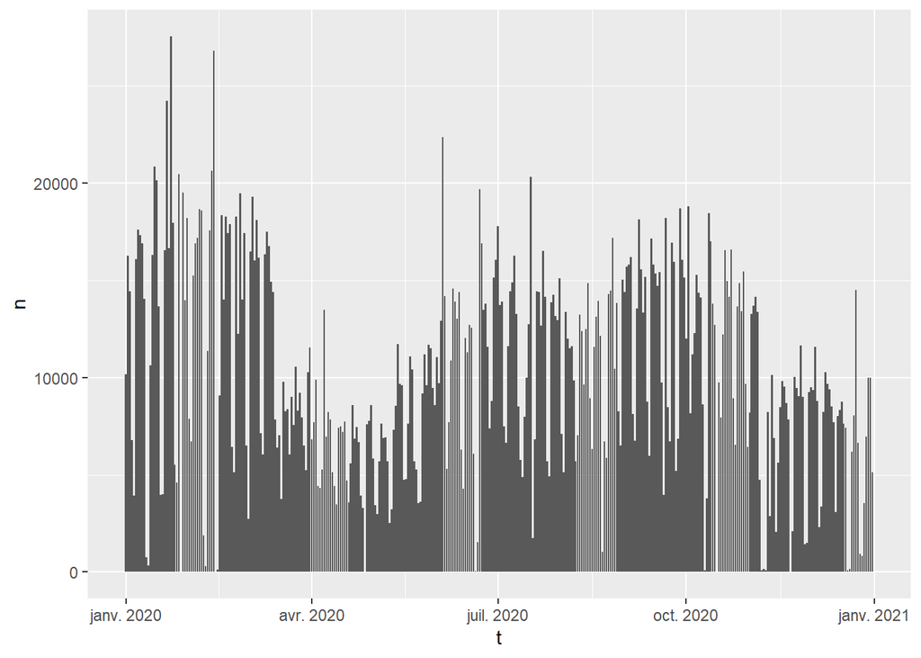

```r
period<-"day"
tab<- don %>% mutate(t=cut(date_sitePublicationDay, breaks=period)) %>% group_by(t) %>% count() %>% mutate(t=as.Date(t))
ggplot(tab) + aes(x=t, y=n)+ geom_col()
```

### Par semaine

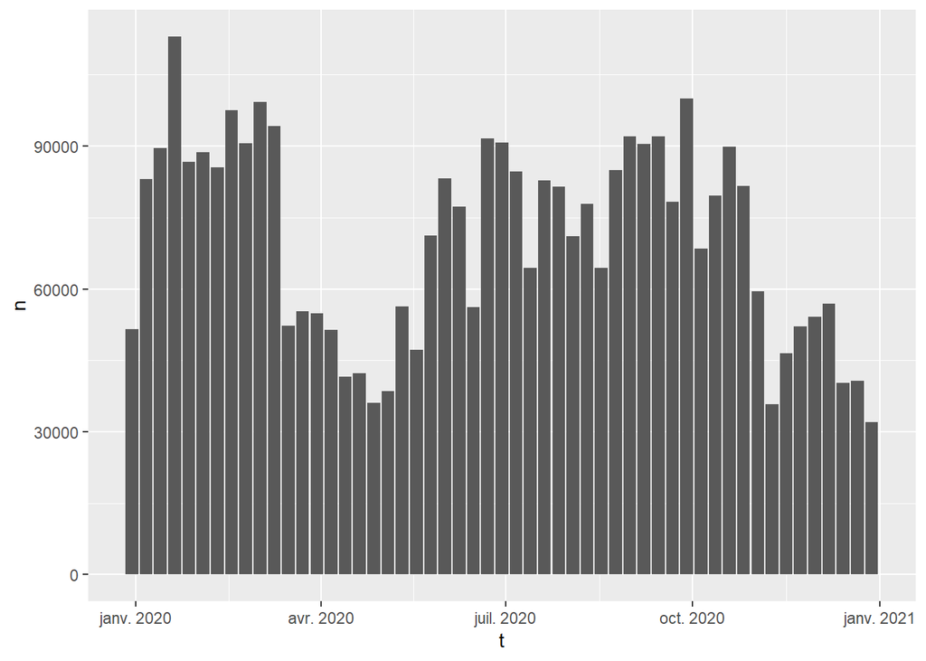

```r
period<-"week"
tab<- don %>% mutate(t=cut(date_sitePublicationDay, breaks=period)) %>% group_by(t) %>% count() %>% mutate(t=as.Date(t))
ggplot(tab) + aes(x=t, y=n)+ geom_col()
```

### Par mois

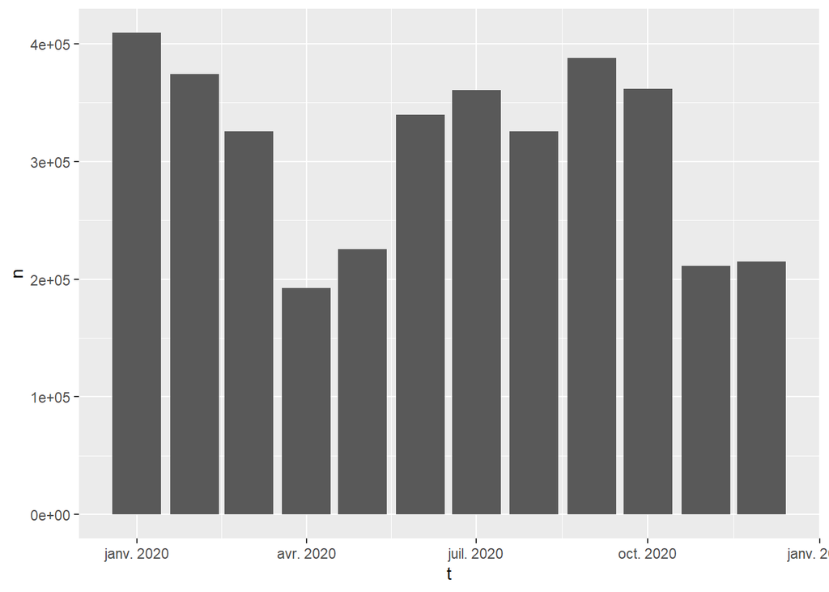

```r
period<-"month"
tab<- don %>% mutate(t=cut(date_sitePublicationDay, breaks=period)) %>% group_by(t) %>% count() %>% mutate(t=as.Date(t))
ggplot(tab) + aes(x=t, y=n)+ geom_col()
```

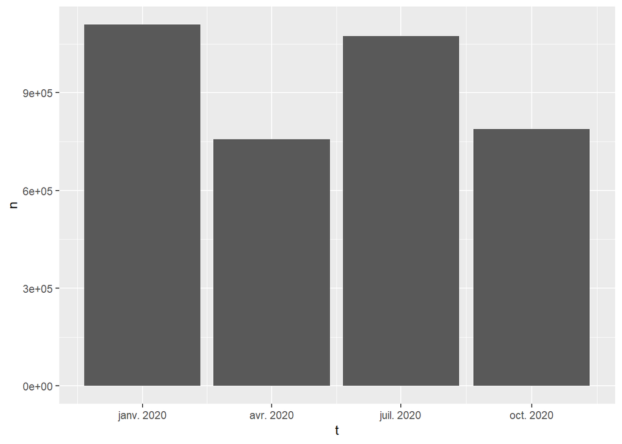

```r
period<-"quarter"
tab<- don %>% mutate(t=cut(date_sitePublicationDay, breaks=period)) %>% group_by(t) %>% count() %>% mutate(t=as.Date(t))
ggplot(tab) + aes(x=t, y=n)+ geom_col()
```

## Analyse sectorielle

Essayons maintenant de classer les offres d’emploi par secteur d’activité des entreprises en utilisant les différentes typologies proposées.

### Récupération des codes NAF

Pour cela nous allons récupérer les code NAF en vigueur à l’aide d’une requête API :

```r
# Classification détaillée
nafcode <- fromJSON("https://public.opendatasoft.com/api/explore/v2.1/catalog/datasets/naf2008/exports/json?lang=fr&timezone=Europe%2FBerlin")

# Classification NAF21
NAF21<-nafcode %>% select(code_section, section) %>% unique() %>% arrange(code_section)
kable(NAF21)
```

| code_section | section |
| --- | --- |
| A | Agriculture, sylviculture et pêche |
| B | Industries extractives |
| C | Industrie manufacturière |
| D | Production et distribution d’électricité, de gaz, de vapeur et d’air conditionné |
| E | Production et distribution d’eau ; assainissement, gestion des déchets et dépollution |
| F | Construction |
| G | Commerce ; réparation d’automobiles et de motocycles |
| H | Transports et entreposage |
| I | Hébergement et restauration |
| J | Information et communication |
| K | Activités financières et d’assurance |
| L | Activités immobilières |
| M | Activités spécialisées, scientifiques et techniques |
| N | Activités de services administratifs et de soutien |
| O | Administration publique |
| P | Enseignement |
| Q | Santé humaine et action sociale |
| R | Arts, spectacles et activités récréatives |
| S | Autres activités de services |
| T | Activités des ménages en tant qu’employeurs ; activités indifférenciées des ménages en tant que producteurs de biens et services pour usage propre |
| U | Activités extra-territoriales |

```r
saveRDS(NAF21,"jocas/data/NAF21.RDS")

# Classification NAF88
NAF88<-nafcode %>% select(code_section,section, code_sous_section, sous_section) %>% unique() %>% arrange(code_section, code_sous_section)
kable(NAF88)
```

| code_section | section | code_sous_section | sous_section |
| --- | --- | --- | --- |
| A | Agriculture, sylviculture et pêche | 01 | Culture et production animale, chasse et services annexes |
| A | Agriculture, sylviculture et pêche | 02 | Sylviculture et exploitation forestière |
| A | Agriculture, sylviculture et pêche | 03 | Pêche et aquaculture |
| B | Industries extractives | 05 | Extraction de houille et de lignite |
| B | Industries extractives | 06 | Extraction d’hydrocarbures |
| B | Industries extractives | 07 | Extraction de minerais métalliques |
| B | Industries extractives | 08 | Autres industries extractives |
| B | Industries extractives | 09 | Services de soutien aux industries extractives |
| C | Industrie manufacturière | 10 | Industries alimentaires |
| C | Industrie manufacturière | 11 | Fabrication de boissons |
| C | Industrie manufacturière | 12 | Fabrication de produits à base de tabac |
| C | Industrie manufacturière | 13 | Fabrication de textiles |
| C | Industrie manufacturière | 14 | Industrie de l’habillement |
| C | Industrie manufacturière | 15 | Industrie du cuir et de la chaussure |
| C | Industrie manufacturière | 16 | Travail du bois et fabrication d’articles en bois et en liège, à l’exception des meubles ; fabrication d’articles en vannerie et sparterie |
| C | Industrie manufacturière | 17 | Industrie du papier et du carton |
| C | Industrie manufacturière | 18 | Imprimerie et reproduction d’enregistrements |
| C | Industrie manufacturière | 19 | Cokéfaction et raffinage |
| C | Industrie manufacturière | 20 | Industrie chimique |
| C | Industrie manufacturière | 21 | Industrie pharmaceutique |
| C | Industrie manufacturière | 22 | Fabrication de produits en caoutchouc et en plastique |
| C | Industrie manufacturière | 23 | Fabrication d’autres produits minéraux non métalliques |
| C | Industrie manufacturière | 24 | Métallurgie |
| C | Industrie manufacturière | 25 | Fabrication de produits métalliques, à l’exception des machines et des équipements |
| C | Industrie manufacturière | 26 | Fabrication de produits informatiques, électroniques et optiques |
| C | Industrie manufacturière | 27 | Fabrication d’équipements électriques |
| C | Industrie manufacturière | 28 | Fabrication de machines et équipements n.c.a. |
| C | Industrie manufacturière | 29 | Industrie automobile |
| C | Industrie manufacturière | 30 | Fabrication d’autres matériels de transport |
| C | Industrie manufacturière | 31 | Fabrication de meubles |

[output cut: 58 more lines]

```r
saveRDS(NAF88,"jocas/data/NAF88.RDS")
```

### Emplois par secteur NAF21

```r
tab<-don %>% mutate(code_section=entrepriseSecteur_NAF21) %>%
             left_join(NAF21) %>%
              filter(is.na(code_section)==F) %>%
              group_by(code_section, section) %>%
              count() %>%
              ungroup() %>%
              mutate(pct = 100*n/sum(n))
kable(tab, digits=c(0,0,0,2))
```

| code_section | section | n | pct |
| --- | --- | --- | --- |
|  | NA | 1658802 | 44.50 |
| C | Industrie manufacturière | 84920 | 2.28 |
| D | Production et distribution d’électricité, de gaz, de vapeur et d’air conditionné | 2055 | 0.06 |
| E | Production et distribution d’eau ; assainissement, gestion des déchets et dépollution | 6087 | 0.16 |
| F | Construction | 72515 | 1.95 |
| G | Commerce ; réparation d’automobiles et de motocycles | 162265 | 4.35 |
| H | Transports et entreposage | 34058 | 0.91 |
| I | Hébergement et restauration | 109736 | 2.94 |
| J | Information et communication | 32841 | 0.88 |
| K | Activités financières et d’assurance | 27131 | 0.73 |
| L | Activités immobilières | 19411 | 0.52 |
| M | Activités spécialisées, scientifiques et techniques | 162813 | 4.37 |
| N | Activités de services administratifs et de soutien | 860981 | 23.10 |
| O | Administration publique | 54064 | 1.45 |
| P | Enseignement | 65902 | 1.77 |
| Q | Santé humaine et action sociale | 257093 | 6.90 |
| R | Arts, spectacles et activités récréatives | 11359 | 0.30 |
| S | Autres activités de services | 64419 | 1.73 |
| T | Activités des ménages en tant qu’employeurs ; activités indifférenciées des ménages en tant que producteurs de biens et services pour usage propre | 41469 | 1.11 |
| U | Activités extra-territoriales | 74 | 0.00 |

### Zoom sur un secteur

```r
tab<-don %>% mutate(code_sous_section=entrepriseSecteur_NAF88) %>%
             left_join(NAF88) %>%
              filter(code_section=="N") %>%
              group_by(code_sous_section, sous_section) %>%
              count() %>%
              ungroup() %>%
              mutate(pct = 100*n/sum(n))
kable(tab, digits=c(0,0,0,2))
```

| code_sous_section | sous_section | n | pct |
| --- | --- | --- | --- |
| 77 | Activités de location et location-bail | 4162 | 0.48 |
| 78 | Activités liées à l’emploi | 775935 | 90.12 |
| 79 | Activités des agences de voyage, voyagistes, services de réservation et activités connexes | 1421 | 0.17 |
| 80 | Enquêtes et sécurité | 16594 | 1.93 |
| 81 | Services relatifs aux bâtiments et aménagement paysager | 46024 | 5.35 |
| 82 | Activités administratives et autres activités de soutien aux entreprises | 16845 | 1.96 |

Hum, cela ne nous avance pas beaucoup … la plupart des emplois de la section N rentrent dans la sous-section 78 “Activités liées à l’emploi” qui semble bien être une catégorie “poubelle” où l’on range les emplois dans des secteurs mal identifiés. Voici la description qu’en donne l’INSEE.

> “Cette division (78) comprend les activités consistant à lister les postes vacants et à orienter ou placer les candidats à l’emploi, les personnes orientées ou placées n’étant pas des salariés des agences de placement, à fournir des travailleurs pour des périodes limitées en vue de compléter la main-d’œuvre du client, ainsi qu’à fournir d’autres ressources humaines.” [source](https://www.insee.fr/fr/metadonnees/nafr2/division/78)

## Analyse spatiale

Nous arrivons à la partie proprement géographique de l’analyse qui est la localisation des emplois proposés. Nous allons commencer par le cas le plus simple qui est la localisation par département. Puis nous examinerons le cas plus compliqué de la localisation par pays (hors de France) et par code postal à Paris et en Petite Couronne.

### Nombre d’emplois par département

On commence par réaliser un tableau du nombre d’emplois par département en nous servant du code fourni dans la variable location_departement.

```r
tabdep<- don %>% group_by(location_departement) %>% count()
kable(tabdep)
```

| location_departement | n |
| --- | --- |
|  | 237206 |
| 01 | 36555 |
| 02 | 16069 |
| 03 | 10887 |
| 04 | 8085 |
| 05 | 8170 |
| 06 | 60364 |
| 07 | 11764 |
| 08 | 9084 |
| 09 | 7372 |
| 1 | 101 |
| 10 | 13334 |
| 11 | 17558 |
| 12 | 12875 |
| 13 | 115264 |
| 14 | 36657 |
| 15 | 5694 |
| 16 | 18649 |
| 17 | 37900 |
| 18 | 14413 |
| 19 | 11791 |
| 2 | 26 |
| 21 | 32661 |
| 22 | 30828 |
| 23 | 4391 |
| 24 | 18743 |
| 25 | 29362 |
| 26 | 32504 |
| 27 | 22235 |
| 28 | 18850 |

[output cut: 87 more lines]

On remarque d’emblée qu’il existe des erreurs puisque certains code n’ont qu’un seul chiffre ce qui est impossible. Les codes à Trois chiffres correspondent quant à eux aux départements, régions et territoires d’oure-mer. Enfin le code 99 correspond aux emplois localisés à l’étranger.On va donc nettoyer le fichier pour ne garder dans un premier temps que les données relatives aux 96 départements de France métropolitaine.

```r
tabdep96<-don %>% mutate(dept=as.character(location_departement)) %>%
                  filter(nchar(dept)==2) %>%
                  filter(!dept %in% c("99","NA")) %>%
                  group_by(dept) %>%
                  count() %>%
                  ungroup() %>%
                  mutate(pct=100*n/sum(n),
                         rang=rank(-n)) %>%
                  arrange(rang)
kable(tabdep96, digits=c(0,0,2,0))
```

| dept | n | pct | rang |
| --- | --- | --- | --- |
| 75 | 175777 | 5.08 | 1 |
| 69 | 164630 | 4.76 | 2 |
| 92 | 134828 | 3.90 | 3 |
| 33 | 122942 | 3.55 | 4 |
| 13 | 115264 | 3.33 | 5 |
| 59 | 111966 | 3.24 | 6 |
| 44 | 108137 | 3.13 | 7 |
| 31 | 91937 | 2.66 | 8 |
| 38 | 79044 | 2.29 | 9 |
| 35 | 72542 | 2.10 | 10 |
| 78 | 70602 | 2.04 | 11 |
| 67 | 67193 | 1.94 | 12 |
| 34 | 62340 | 1.80 | 13 |
| 06 | 60364 | 1.75 | 14 |
| 77 | 58896 | 1.70 | 15 |
| 94 | 56604 | 1.64 | 16 |
| 74 | 54366 | 1.57 | 17 |
| 91 | 54173 | 1.57 | 18 |
| 93 | 53314 | 1.54 | 19 |
| 85 | 53284 | 1.54 | 20 |
| 83 | 52975 | 1.53 | 21 |
| 49 | 51456 | 1.49 | 22 |
| 76 | 48790 | 1.41 | 23 |
| 29 | 48777 | 1.41 | 24 |
| 57 | 45880 | 1.33 | 25 |
| 56 | 44911 | 1.30 | 26 |
| 62 | 43774 | 1.27 | 27 |
| 95 | 42164 | 1.22 | 28 |
| 73 | 38833 | 1.12 | 29 |
| 45 | 38459 | 1.11 | 30 |

[output cut: 66 more lines]

Notre fichier est désormais propre et on peut reprérer le code des départements qui concentrent le plus d’offre d’emploi (75, 69, 92, 33, 13 …) et ceux qui en offrent le moins (48, 23, 15, 2B, 90, 2A,…). Ce résultat est toutefois assez frustrant puisqu’on ne connait pas le nom des départements ni leur localisation spatiale, sauf si on est un expert dans les jeux télévisés …

### Importation d’un fonds de carte des départements

Nous allons donc utiliser à nouveau une requête APi pour récupérer un fonds de carte des départements français au format geojson et le transformer en fichier sf. On va choisir de préférence un fonds de carte aux contours très simplifiés pour obtenir une jolie carte. Ce que nous cherchons se trouve [ici](https://public.opendatasoft.com/explore/dataset/contours-geographiques-tres-simplifies-des-departements-2019/information/?refine.insee_dep=05). On récupère l’url pour télécharger le fonds de carte complet et on l’e l’importe dans R à l’aide de la fonction `st_read()` du package sf.

```r
url<-"https://public.opendatasoft.com/api/explore/v2.1/catalog/datasets/contours-geographiques-tres-simplifies-des-departements-2019/exports/geojson?lang=fr&timezone=Europe%2FBerlin"
mapdep<-st_read(url)
class(mapdep)
```

```
[1] "sf"         "data.frame"
```

On peut vérifier que l’objet obtenu possède une double classe *data.frame* et *sf*. Il comporte une variable **geometry** que l’onpeut utiliser pour tracer rapidement le fonds de carte.

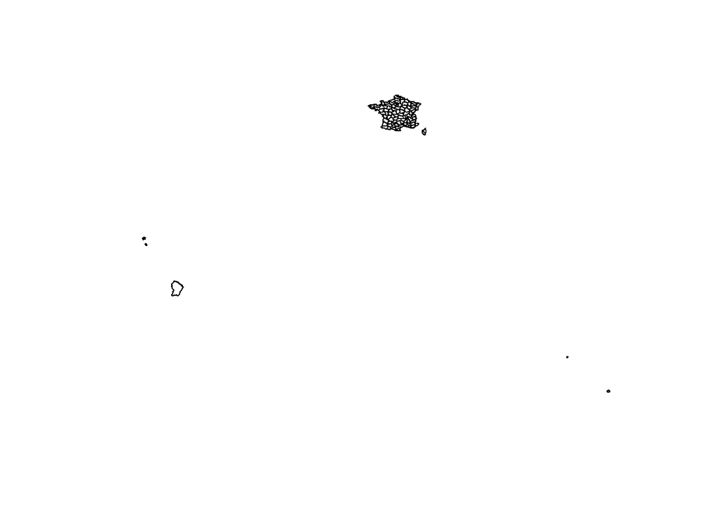

```r
plot(mapdep$geometry)
```

Evidemment la carte n’est pas très jolie en raison de la présence des départements et territoires d’outre-mer. Quant à la France elle a une forme un peu bizarre liée au choix de la projection par défaut.

### Sélection de la France métropolitaine et projection

On va nettoyer le fonds de carte en ne conservant que les départements de France métropolitaine.

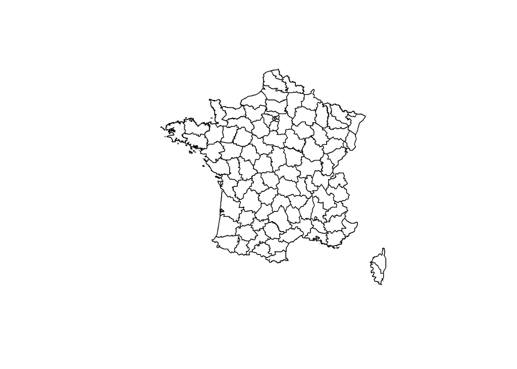

```r
mapdep96 <- mapdep %>% filter(nchar(insee_dep)==2)
plot(mapdep96$geometry)
```

On a bien désormais la France métropolitaine. Mais si vous êtes habitués aux cartes de l’INSEE, vous trouverez sans doute que la France a une forme un peu trop large au Nord. Cela s’explique par la projection utilisée par défaut. On peut corriger cela en modifiant les coordonnées avec la fonction `st_transform()` du package sf en retenant la projection 2154.

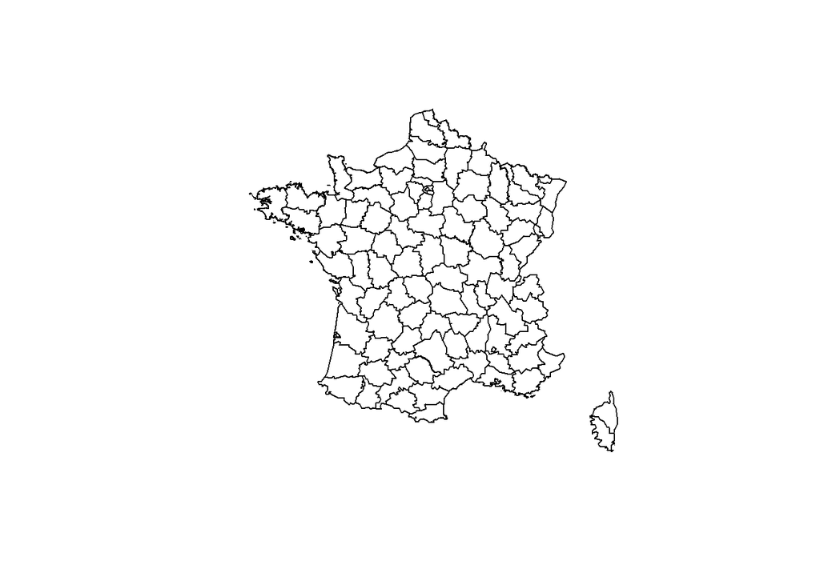

```r
mapdep96 <-st_transform(mapdep96, crs = 2154)
plot(mapdep96$geometry)
```

### Jointure avec les données d’emploi

Nous allons maintenant effectuer la jointure entre ce fonds de carte et les données d’offre d’emploi en utilisant une variable commune qui sera ici le code des départements. On conserve le nom du département et de la région.

```r
mapdon<- mapdep96 %>%
          rename(dept=insee_dep) %>%
           select(dept,nom_dep,region) %>%
          left_join(tabdep96)
kable(head(mapdon))
```

| dept | nom_dep | region | n | pct | rang | geometry |
| --- | --- | --- | --- | --- | --- | --- |
| 22 | COTES-D’ARMOR | BRETAGNE | 30828 | 0.8912598 | 43 | MULTIPOLYGON (((320499.7 68… |
| 35 | ILLE-ET-VILAINE | BRETAGNE | 72542 | 2.0972418 | 10 | MULTIPOLYGON (((331908.5 68… |
| 87 | HAUTE-VIENNE | NOUVELLE-AQUITAINE | 13735 | 0.3970888 | 69 | MULTIPOLYGON (((531944 6561… |
| 11 | AUDE | OCCITANIE | 17558 | 0.5076145 | 61 | MULTIPOLYGON (((719520.2 62… |
| 03 | ALLIER | AUVERGNE-RHONE-ALPES | 10887 | 0.3147511 | 78 | MULTIPOLYGON (((702445.6 66… |
| 59 | NORD | HAUTS-DE-FRANCE | 111966 | 3.2370182 | 6 | MULTIPOLYGON (((706763.6 70… |

### Cartographie basique avec sf

On peut produire des cartes simples en utilisant les fonctions de sf et de Rbase. Mais il faut éviter de commettre des erreurs de syntaxe graphique. Voici quelques exemples de cartes justes ou fausses.

#### Carte des régions

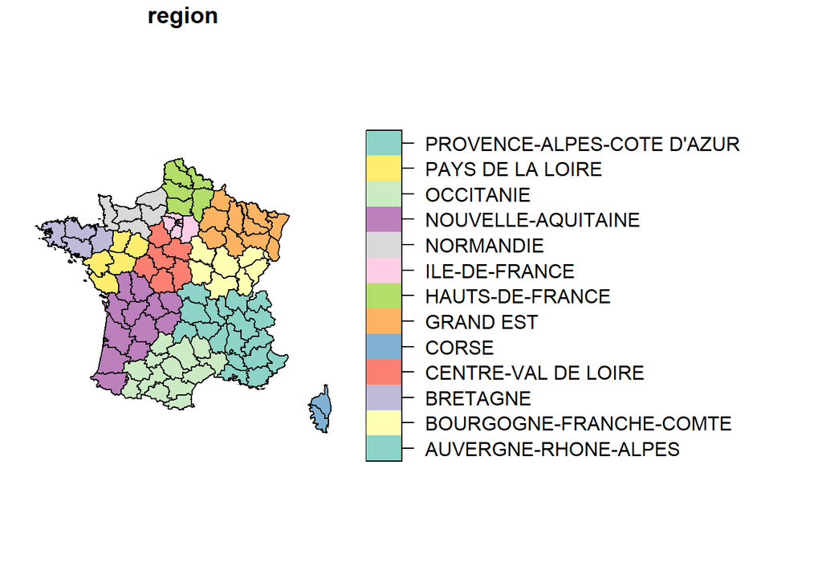

```r
plot(mapdon["region"],)
```

Pas très jolie mais juste

#### Carte des offres d’emploi (fausse)

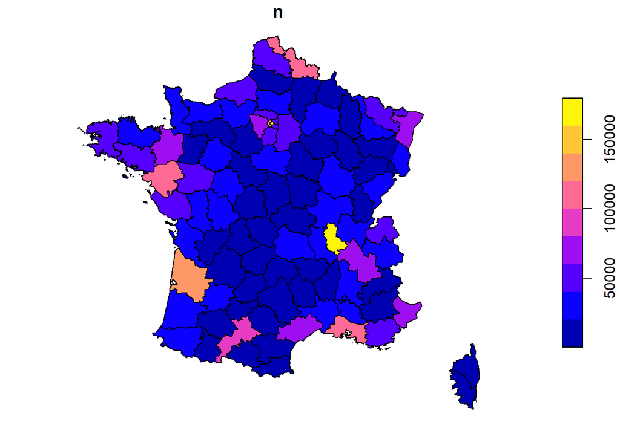

```r
plot(mapdon["n"])
```

Carte fausse car elle représente des **stocks** qui doivent être représentées sous la forme de cercles proportionnels.

#### Carte des offres d’emploi (juste mais sans légende)

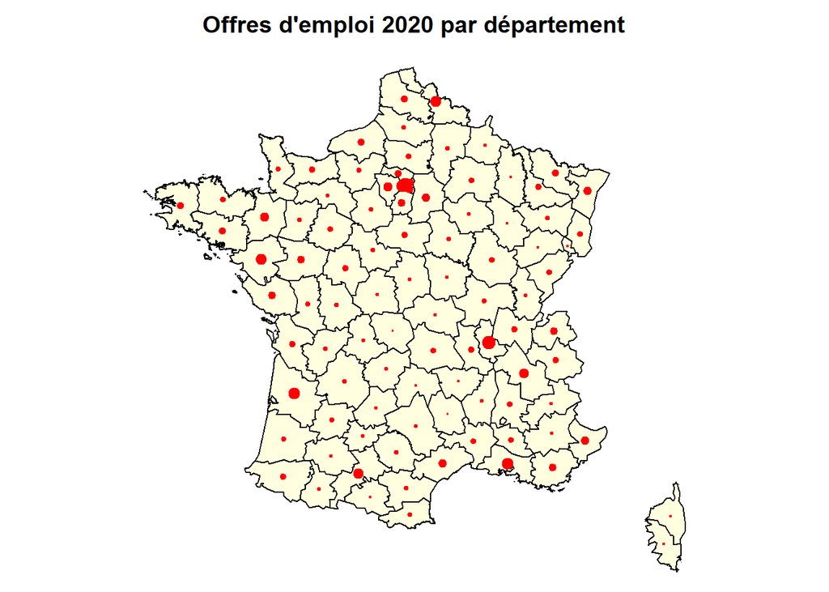

```r
par(mar=c(0,0,2,0))
plot(mapdon$geometry, col="lightyellow")
plot(st_centroid(mapdon$geometry),
     cex=sqrt(mapdon$pct),
     add=T,
     col="red",
     pch=20)
title(main = "Offres d'emploi 2020 par département",
      sub = "Source : Base JOCAS")
```

Les cercles sont bien proportionnels mais la carte n’a pas de légende